# Untitled

Sayani Gupta

25/08/2019

# Case study: Analysis on smart meter data

Smart meters provide large quantities of measurements on energy usage for households across Australia, and indeed many parts of the world. Households are distributed geographically, and have different demographic properties such as the existence of solar panels, central heating or air conditioning. The behavioral patterns in households vary substantially, for example, some families use a dryer for their clothes while others hang them on a line, and some households might consist of night owls, while others are morning larks.

It is common to see aggregates of usage across households, total kwh used each half hour by state, for example, because energy companies need to understand maximum loads that they will have to plan ahead to accommodate. But studying overall energy use hides the distributions of usage at finer scales, and making it more difficult to find solutions to improve energy efficiency.

One of the customer trial [@smart-meter] conducted as part of the Smart Grid Smart City (SGSC) project (2010-2014) in NewCastle, New South Wales and some parts of Sydney provides customer wise data on half hourly energy usage and detailed information on appliance use, climate, retail and distributor product offers, and other related factors. It would be interesting to explore the energy consumption distribution for these customers and gain more insights on their energy behavior which are otherwise lost either due to aggregation or looking only at coarser temporal units. The idea here is to show how looking at time across different granularities together can help identify different behavioral patterns.

Let us compare the energy consumption distribution for two households from the customer trials. For the purpose of this analysis, we only take the data for the year 2013. Let us look at the distribution of energy across coarser temporal granularities and then deep dive into finer temporal granularities.

- Hourly usage across months of the year

Let us dive deeper and see the hourly usage across different days of the week for these two households.

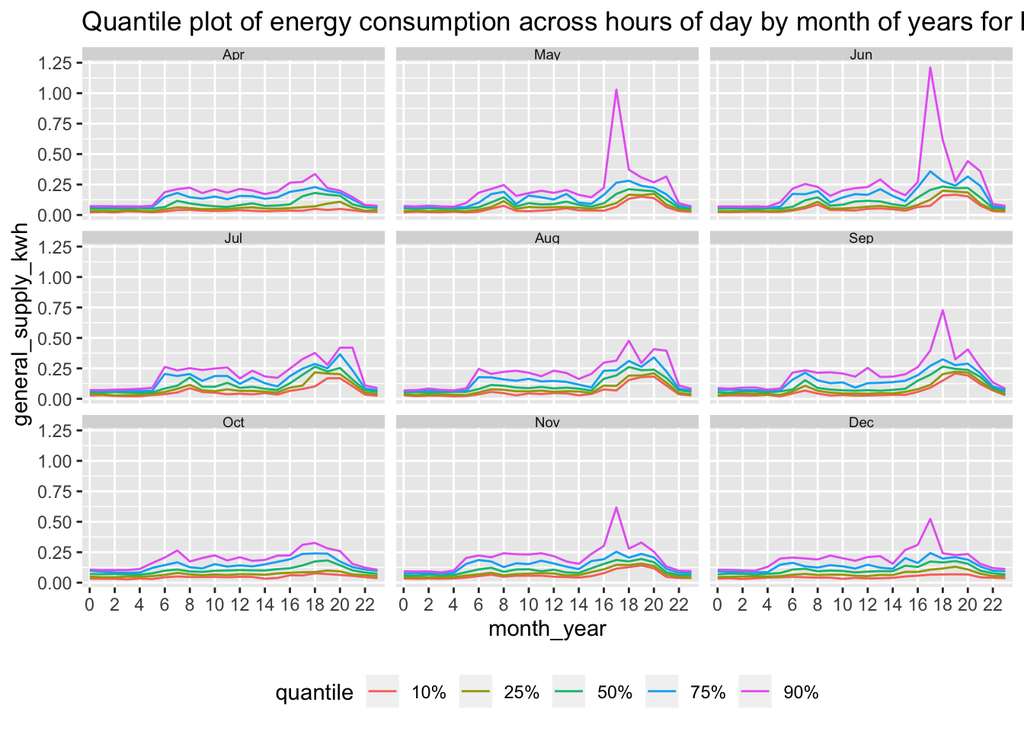

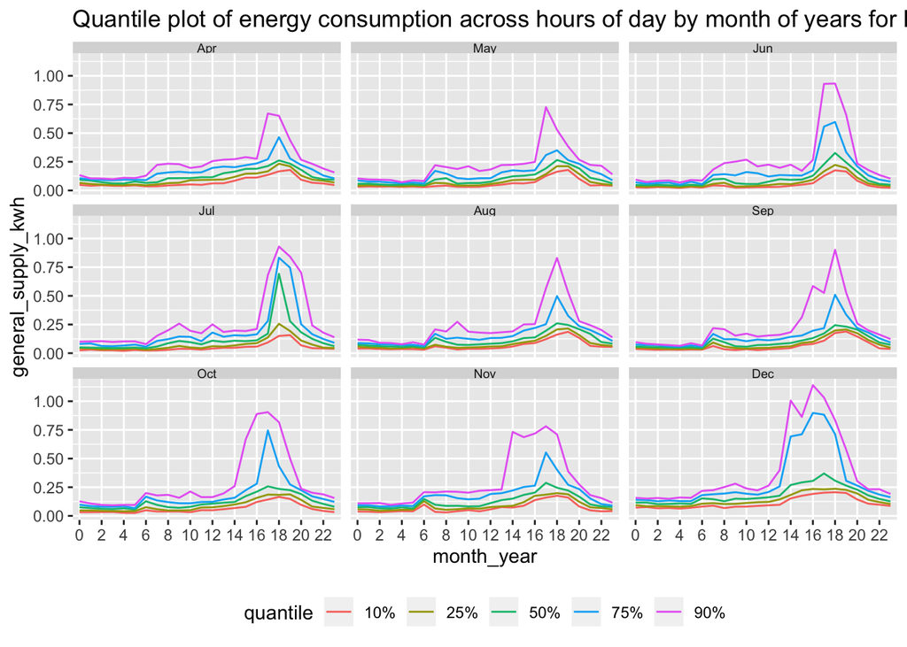

- Hourly usage across days of the week

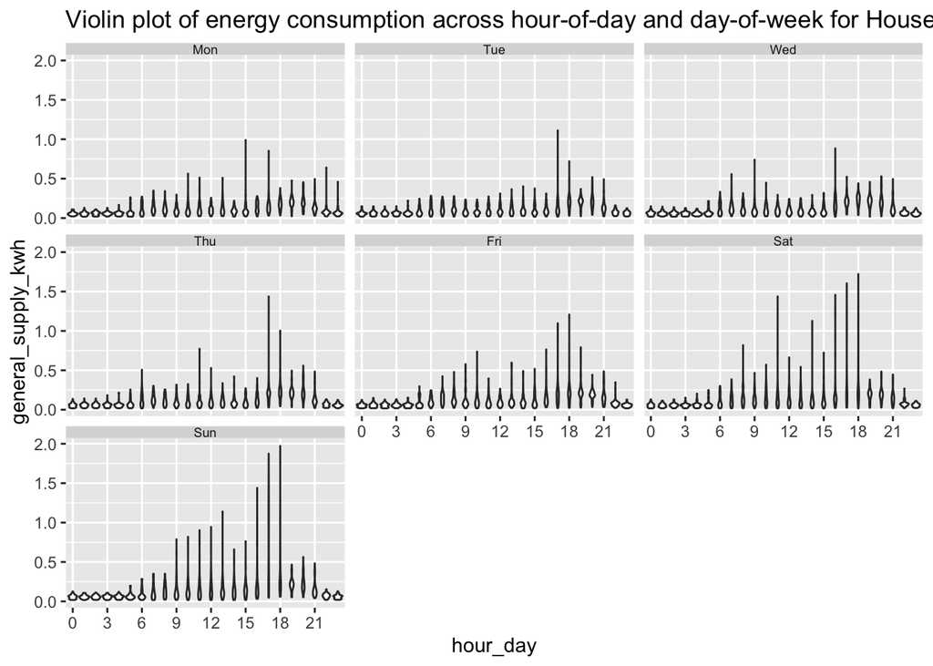

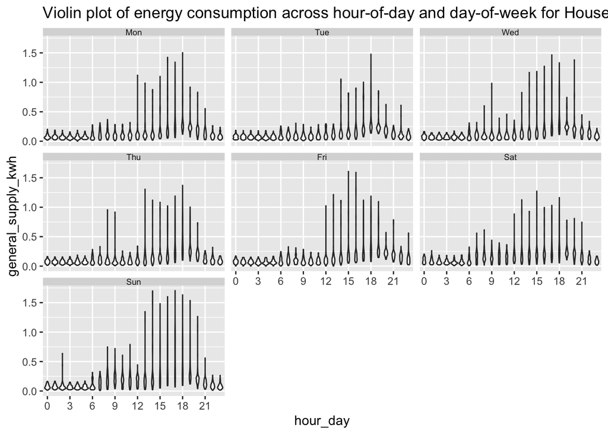

shows distribution of hourly energy usage for two households across different days of the week through violin plots for Household 1. Energy consumption typically goes up between 16 to 18 hours. On weekends, the energy consumption for these hours are even higher. The straight lines in the violin plot for weekends at 17th and 18th hours suggest that the distribution of energy consumption is uniform demonstrating that any energy value has equal probability in falling in that hour. This suggests that these hours are extremely volatile based on weather conditions/months. Energy consumption distribution in the morning hours of weekdays have a bulge between 0 to 0.25 KwH, indicating that if we pick up any typical week day, we can say with reasoable certainty that the energy consumption would fall in that range. This is not true for the 17th or 18th hour of the day. The consistent behavior in the morning hours can be attributed to the fact that members in this household are not stay-at-home professionals.

shows distribution of hourly energy usage for two households across different days of the week through violin plots for Household 2. Contrary to Household 1, Household 2’s energy consumption increases through noon through 7pm. We can’t say with certainty if the morning hours from 10am would manifest a higher or lower level of energy consumption from the households. This indicates that this household might have kids or someone working from home.

A plot of the distribution across months of the year and days of the week might throw some light on the extreme behavior we saw in May and June. Was it only for the months May and June, that this household consumed more energy than they usually do? shows that it is not only those months that saw high energy consumption on Saturday and Sundays. In fact, months like November and December saw higher energy usage than typical even on other weekdays. Still for this household, it can be safely said that most of their activities which involve higher energy consumption are concentrated on weekends. The behavior of the weekends, as can be observed from the letter values of energy consumption, are different across months which can be attributed to weather conditions.

- Across days of the week by months

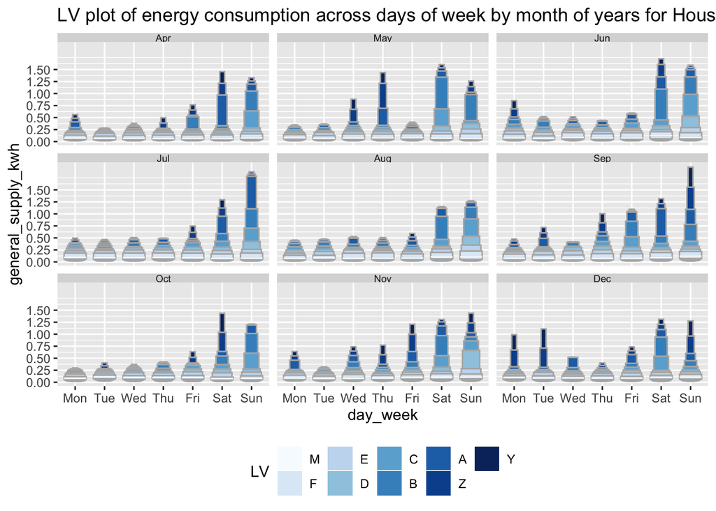

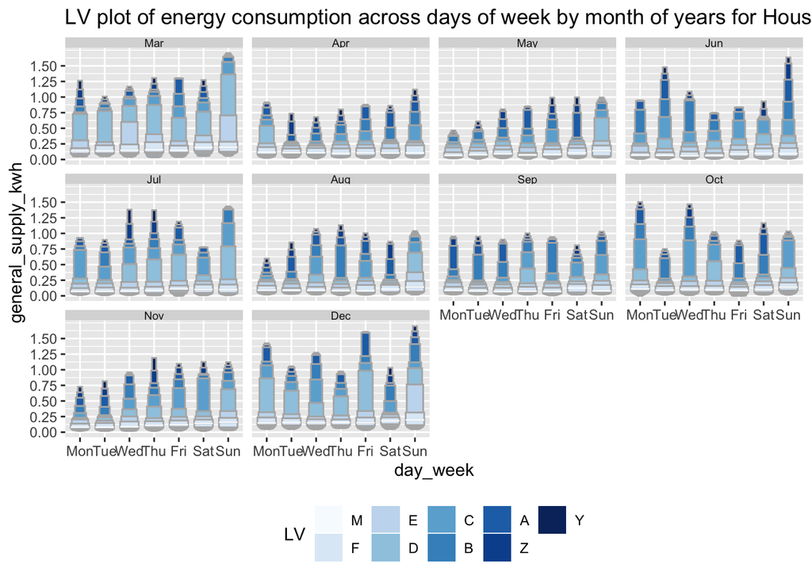

To summarise, we can posit the following for the two households:

- First household tpically doesn’t routinely use air conditioners in summer(December), or heaters in winter months (May and June). They are strictly 9 to 5 professsionals, hence their energy consumption during day time is pretty consistent and only peaks up during few hours in the evening. They do all energy intensive chores (e.g. laundry, vacuum cleaning) mostly in the evenings of weekends.
- Second household tpically use air conditioners in summer months and heaters in winter months. This might be a family with children with stay-at-home parents/ work-from-home professionals with extremely varying energy consumption peaking up from noon. Their weekday behavior is not distinctly different from weekends. Also, they are more likely to distribute their energy intensive chores through out the week and not leave all them for the weekends.

We can keep on slicing and dicing the data in a similar fashion and derive more insights about the behavior of these households.